# Optimizing Consistency Methods

Rémy Lachelin<sup>1,</sup> remy.lachelin@fernuni.ch Chhavi Sachdeva<sup>1,</sup> chhavi.sachdeva@unidistance.ch

##### Nicolas Rothen<sup>1,</sup>

<sup>1</sup> Department of Psychology, UniDistance Suisse

# Introduction

**Sequence-Space Synaesthesia (SSS)**, is the phenomenon where people visualize ordered sequences in consistent spatial positions (Flournoy, 1893; Galton, 1880). **Consistency tasks** classify SSS from controls by having participants indicate perceived spatial positions for a stimuli on a screen. Because of SSS internal spatial representations responses are more consistent than those of controls. Existing **consistency methods** (i.e. Rothen et al., 2016) test the spatial variability to the same stimuli, here we explored novel consistency methods.

# Methods

**Consistency tasks** measure the responses (as a *x,y* screen position) for weekdays (Mon-Sun), months (Jan-Dec) and numbers (1-9), each repeated three times. The novel **consistency methods** *B)* and *D)* evaluate participant’s *space-form* consistency (Figure 1).

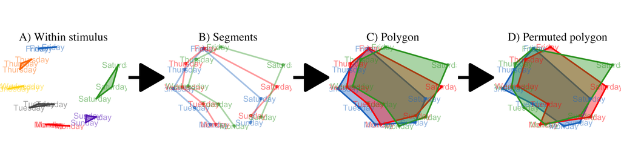

[figure not shown]

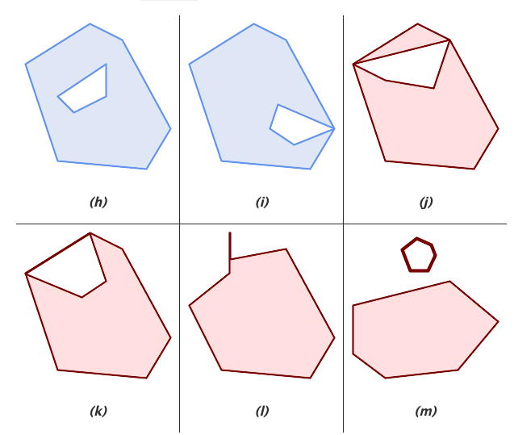

*isValid* evaluates if a polygon is topologically valid (i.e. blue polygons) or not (i.e. red polygons). Topologically valid is defined by the Open Geospatial Consortium (Herring, 2010) with the *PostGIS 3.6.2dev Manual* (n.d.) cartography tools.

## Aggregated datasets of consistency tasks

We aggregated four available datasets using the same consistency task (Rothen et al., 2016; Van Petersen et al., 2020; Ward, 2022) and Ward (2025, personal communication). Original groups are defined by self-report of having SSS or not (i.e. controls).

[output not shown]

# Results

Receiver Operator Curves (ROC) of each consistency methods show the sensitivity (SSS classified as SSS) and sensibility (control as controls) by moving threshold for each consistency method.

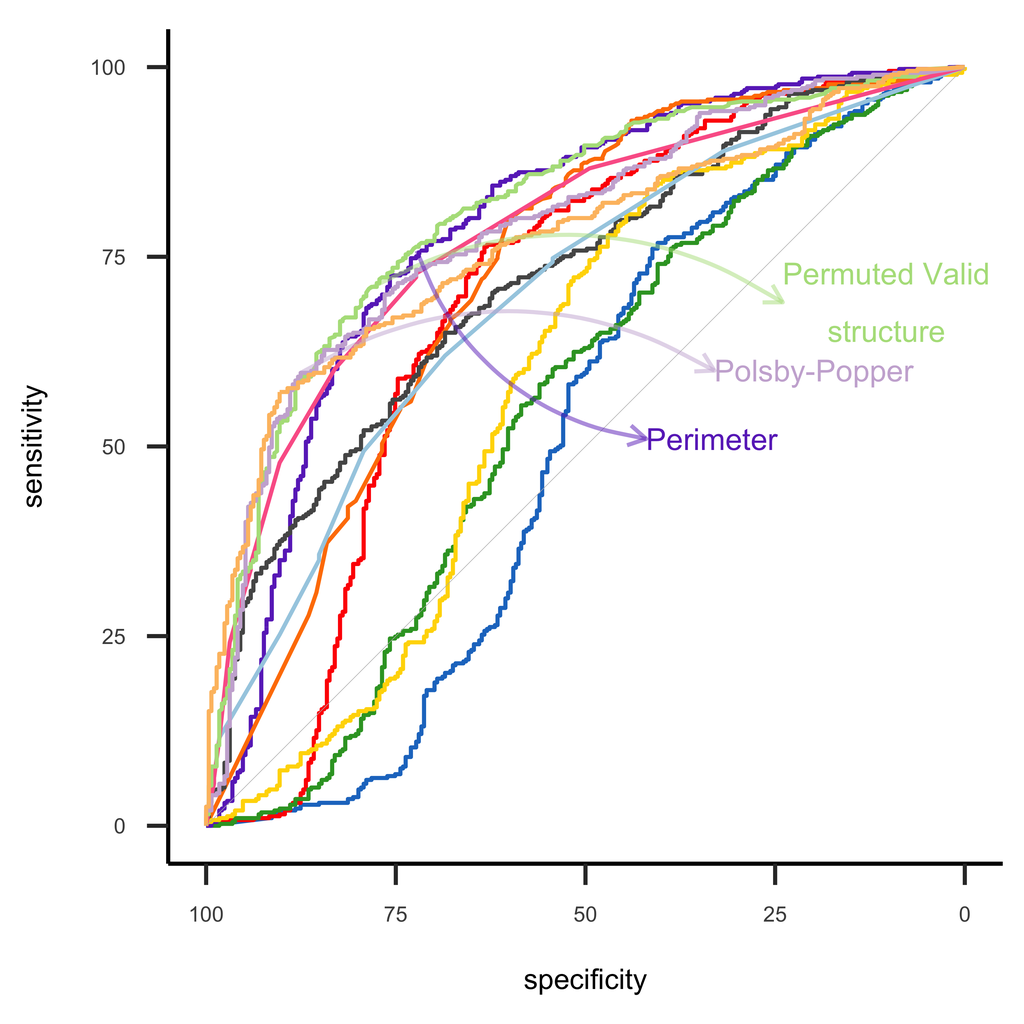

| Feature | AUC | threshold | sensitivity | specificity | accuracy |
| --- | --- | --- | --- | --- | --- |
| Permuted valid structure [boolean/9] | 81.16 | 0.17 | 70.78 | 78.55 | 74.05 |
| Polsby–Popper [score/9] | 78.96 | 0.19 | 59.70 | 87.54 | 71.43 |
| Perimeter [z-score] | 78.80 | 1.73 | 72.54 | 75.78 | 73.91 |
| Valid structure [boolean/9] | 78.12 | 0.14 | 72.80 | 72.32 | 72.59 |
| Permuted P-P [score/9] | 77.14 | 0.20 | 57.18 | 90.31 | 71.14 |
| Segment self-intersections [n/9] | 72.93 | 1.17 | 79.85 | 60.21 | 71.57 |
| Area of the polygon [z-score] | 72.03 | 1.29 | 64.99 | 68.51 | 66.47 |
| Simple topology [boolean/9] | 69.74 | 0.28 | 61.96 | 68.51 | 64.72 |
| Area [z-score] | 69.27 | 0.08 | 76.32 | 63.32 | 70.85 |
| Perimeter of the polygon [z-score] | 59.12 | 10.46 | 83.88 | 41.87 | 66.18 |
| Perimeter [screen size %] | 55.34 | 0.03 | 76.07 | 38.75 | 60.35 |
| Area [screen size %] | 50.87 | 0.21 | 76.83 | 40.48 | 61.52 |

AUC = Area Under the Curve. Threshold calculated on the AUC with Youden's index.

**Permuted validity** and **standardized perimeter** led to comparably high AUC (*D* = 1.36, *n.s.*). **Polsby-Popper**, differed from permuted validity (*D* = 2.06, *p* < .05).

However some results varied depending on the datasets:

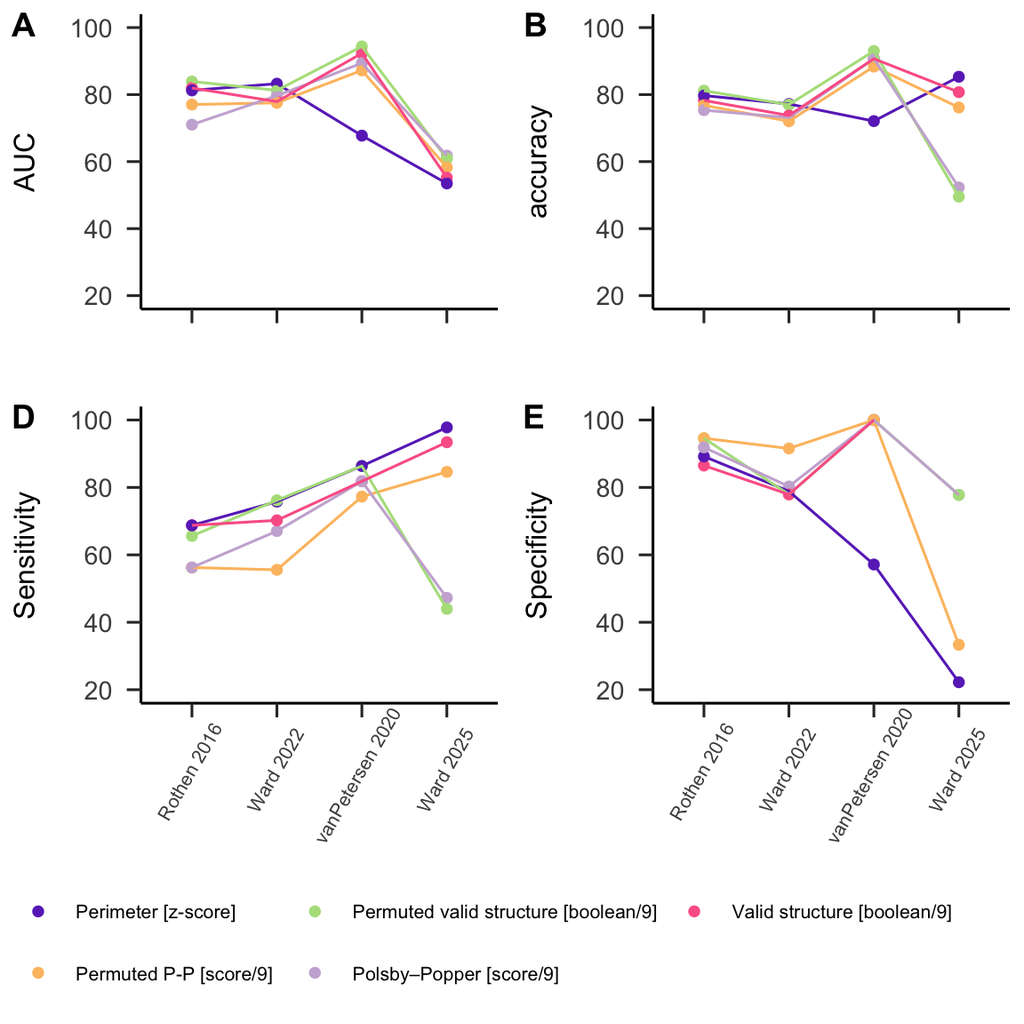

# Discussion

- Permuted validity underlines the possible role of topological rules for SSS space-forms, with the 0.17 cut-off reflecting an average of 1.53 valid forms out of 9.
- Polsby-popper score (Polsby & Popper, 1991), originally designed to measure district compactness, performs surprisingly well in distinguishing SSS from controls, tough it’s low sensitivity.
- Perimeter captures spatial variability within stimuli.

Earlier methods (Rothen et al., 2016) allowed controls to achieve artificially high consistency by clicking on the same position. While this limitation is adressed by novel methods. However, these interoduces a new issue: reduced detection of zig-zag SSS space-forms. Moreover, both methods lead to comparable classification performances. Overall, we find some heterogeneities in classification performances across datasets, motivating additional further valiadation in *Phase II* on yet-to-be collected data.

In sum, validity is as effective as previous methods for classifying SSS. Nevertheless, these results suggests the space-forms of SSS might be mapped following topographical rules such as for cartography.

# References

This is a reproducible poster using the ‘posterdown’ package version 1.0 (Thorne, 2019). Follow the QR code link for the code and data.

Flournoy, T. (1893). *Des phénomènes de synopsie (audition colorée): Photismes, schèmes visuels, personnifications*. Alcan. https://books.google.bj/books?id=JISQxpcyGUMC

Galton, F. (1880). Visualised numerals. *Nature*, *21*(533), 252–256. https://doi.org/10.1038/021252a0

Herring, J. R. (2010). *OpenGIS® implementation standard for geographic information - simple feature access - part 1: Common architecture*.

Polsby, D. D., & Popper, R. (1991). The third criterion: Compactness as a procedural safeguard against partisan gerrymandering. *SSRN Electronic Journal*. https://doi.org/10.2139/ssrn.2936284

*PostGIS 3.6.2dev manual*. (n.d.).

Rothen, N., Jünemann, K., Mealor, A. D., Burckhardt, V., & Ward, J. (2016). The sensitivity and specificity of a diagnostic test of sequence-space synesthesia. *Behavior Research Methods*, *48*(4), 1476–1481. https://doi.org/10.3758/s13428-015-0656-2

Thorne, W. B. (2019). *posterdown: An R package built to generate reproducible conference posters for the academic and professional world where powerpoint and pages just won’t cut it*. https://github.com/brentthorne/posterdown

Van Petersen, E., Altgassen, M., Van Lier, R., & Van Leeuwen, T. M. (2020). Enhanced spatial navigation skills in sequence-space synesthetes. *Cortex*, *130*, 49–63. https://doi.org/10.1016/j.cortex.2020.04.034

Ward, J. (2022). *Optimizing a measure of consistency for sequence-space synaesthesia*. https://osf.io/5cnr7_v1

Mapping **Synesthetic Sequences in Space**: Improving **Consistency Test** by Harnessing **Cartography Tools**

[figure not shown]